# Ch 1 excercises

Julia Grabow

2023-08-07

Packages used

```r
library(tidyverse)
library(ggExtra)
```

Exercise 1.1:

```r
x1 <-
  c(3, 4, 2, 6, 8, 2, 5)
x2 <-
  c(5, 5.5, 4, 7, 10, 5, 7.5)
```

Mean of x1 and x2:

```r
xbar1 <- mean(x1)

xbar2 <- mean(x2)

print(xbar1)
```

```
## [1] 4.285714
```

```r
print(xbar2)
```

```
## [1] 6.285714
```

Variances of s11 and s22 and covariance s12: Remember, in this textbook, author uses population variance and covariance rather than sample variance and covariance s11

```r
(1/7) * sum(
  ((x1-xbar1)^2)
)
```

```
## [1] 4.204082
```

s22

```r
(1/7) * sum(
  ((x2-xbar2)^2)
)
```

```
## [1] 3.561224
```

s12

```r
(1/7) * sum(
  ((x1-xbar1) * (x2-xbar2))
)
```

```
## [1] 3.704082
```

Exercise 1.2

```r
age_yrs <-
  c(1, 2, 3, 4, 5, 6, 7, 8, 9, 11)

price_dollars <-
  c(18.95, 19.00, 17.95, 15.54, 14.00, 12.95, 8.94, 7.49, 6.00, 3.9)
```

1. Scatterplot with dot diagram or histograms:

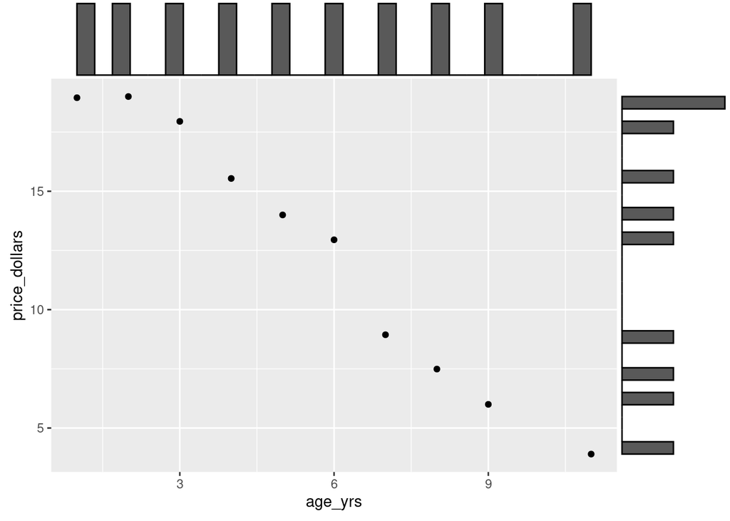

```r
p <-
  ggplot() +
  geom_point(
    mapping = aes(
      x = age_yrs,
      y = price_dollars
    )
  )

ggMarginal(
  p,
  type = "histogram"
)
```

2. infer sign of sample covariance: As age increases, price decreases, so I expect this to have a negative covariance
3. Sample mean of age:

```r
mean_age <- mean(age_yrs)
print(mean_age)
```

```
## [1] 5.6
```

Sample mean of price_dollars:

```r
mean_price <- mean(price_dollars)
print(mean_price)
```

```
## [1] 12.472
```

Sample variance of age:

```r
var(age_yrs)
```

```
## [1] 10.26667
```

```r
var_age <- var(age_yrs)
```

Sample variance of price

```r
var(price_dollars)
```

```
## [1] 31.025
```

```r
var_price <- var(price_dollars)
```

Sample covariance of age and price:

```r
cov(age_yrs, price_dollars)
```

```
## [1] -17.59689
```

```r
covariance_age_price <- cov(age_yrs, price_dollars)
```

Sample correlation coefficient:

```r
cor(age_yrs, price_dollars)
```

```
## [1] -0.9859736
```

```r
correlation_age_price <- cor(age_yrs, price_dollars)
```

Sample mean array (x bar):

```r
array(
  list(
    mean_age,
    mean_price
  ),
  dim = c(
    2, 1
  )
)
```

```
##      [,1]
## [1,] 5.6
## [2,] 12.472
```

Sample variance-covariance array (Sn):

```r
array(
  data = list(
    var_age,
    covariance_age_price,
    covariance_age_price,
    var_price
  ),
  dim = c(
    2, 2
  )
)
```

```
##      [,1]      [,2]
## [1,] 10.26667  -17.59689
## [2,] -17.59689 31.025
```

Sample correlation array (R):

```r
array(
  data = list(
    1, correlation_age_price, correlation_age_price, 1
  ),
  dim = c(2, 2)
)
```

```
##      [,1]       [,2]
## [1,] 1          -0.9859736
## [2,] -0.9859736 1
```

1.3 Values:

```r
x3.1 <-
  c(9, 2, 6, 5, 8)
x3.2 <-
  c(12, 8, 6, 4, 10)
x3.3 <-
  c(3, 4, 0, 2, 1)
```

Sample mean array:

```r
array(
  data = list(
    mean(x3.1),
    mean(x3.2),
    mean(x3.3)
  ),
  dim = c(3, 1)
)
```

```
##      [,1]
## [1,] 6
## [2,] 8
## [3,] 2
```

Sample variances and covariances:

```r
array(
  data = list(
    var(x3.1),
    cov(x3.1, x3.2),
    cov(x3.1, x3.3),
    cov(x3.2, x3.1),
    var(x3.2),
    cov(x3.2, x3.3),
    cov(x3.3, x3.1),
    cov(x3.3, x3.2),
    var(x3.3)
  ),
  dim = c(3, 3)
)
```

```
##      [,1]  [,2] [,3]
## [1,] 7.5   5    -1.75
## [2,] 5     10   1.5
## [3,] -1.75 1.5  2.5
```

Sample correlation array:

```r
array(
  data = list(
    1,
    cor(x3.1, x3.2),
    cor(x3.1, x3.3),
    cor(x3.2, x3.1),
    1,
    cor(x3.2, x3.3),
    cor(x3.3, x3.1),
    cor(x3.3, x3.2),
    1
  ),
  dim = c(3, 3)
)
```

```
##      [,1]       [,2]      [,3]
## [1,] 1          0.5773503 -0.4041452
## [2,] 0.5773503  1         0.3
## [3,] -0.4041452 0.3       1
```

1.4 Create dataframe:

```r
company <-
  c(
    "Citigroup",
"General Electric",
"American Int! Group",
"Bank of America",
"HSBCGroup",
"ExxonMobil",
"Royal Dutch/Shell",
"BP",
"INGGroup",
"Toyota Motor"
)
sales_billions <-
  c(
    108.28,
152.36,
95.04,
65.45,
62.97,
263.99,
265.19,
285.06,
92.01,
165.68
  )
profits_billions <-
  c(
    17.05,
16.59,
10.91,
14.14,
9.52,
25.33,
18.54,
15.73,
8.10,
11.13
  )
assets_billions <-
  c(
    1484.10,
750.33,
766.42,
1110.46,
1031.29,
195.26,
193.83,
191.11,
1175.16,
211.15
  )
df4 <-
  data.frame(
    company,
    sales_billions,
    profits_billions,
    assets_billions
  )
print(df4)
```

```
##                company sales_billions profits_billions assets_billions
## 1            Citigroup         108.28            17.05         1484.10
## 2     General Electric         152.36            16.59          750.33
## 3  American Int! Group          95.04            10.91          766.42
## 4      Bank of America          65.45            14.14         1110.46
## 5            HSBCGroup          62.97             9.52         1031.29
## 6           ExxonMobil         263.99            25.33          195.26
## 7    Royal Dutch/Shell         265.19            18.54          193.83
## 8                   BP         285.06            15.73          191.11
## 9             INGGroup          92.01             8.10         1175.16
## 10        Toyota Motor         165.68            11.13          211.15
```

Scatterplot with marginal histograms of sales and profits:

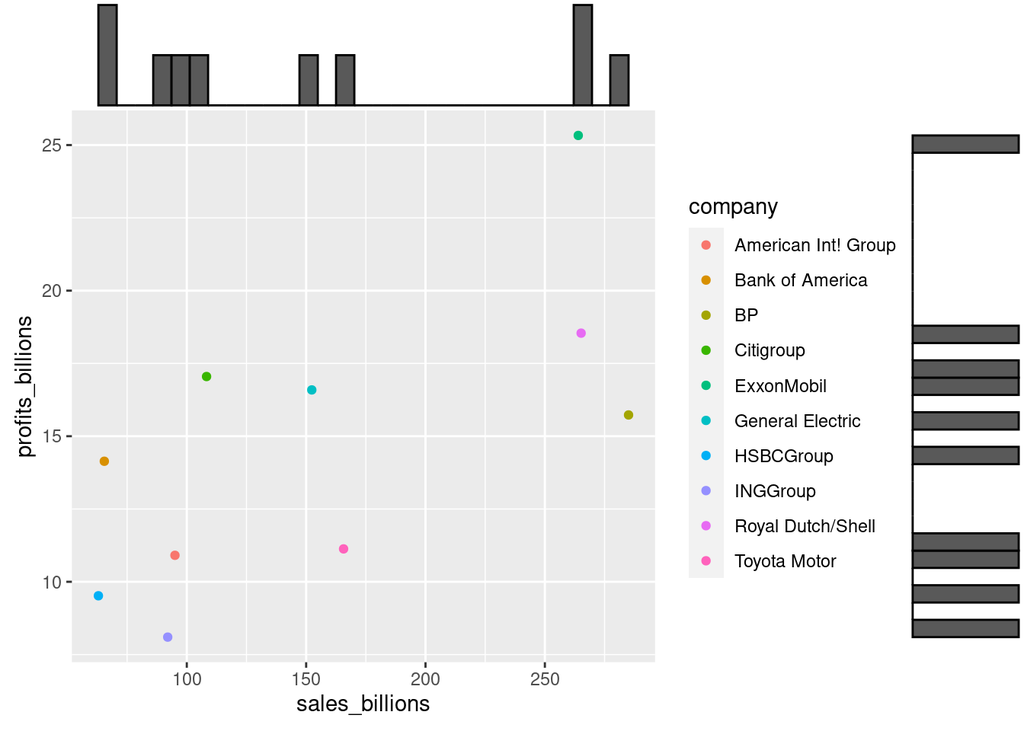

```r
p4 <-
  ggplot() +
  geom_point(
    mapping = aes(
      x = sales_billions,
      y = profits_billions,
      color = company
    )
  )
ggMarginal(
  p4,
  type = "histogram"
)
```

2. Sample means:

```r
colMeans(
  df4[
    sapply(
      df4, is.numeric
    )
  ]
)
```

```
##   sales_billions profits_billions  assets_billions
##          155.603           14.704          710.911
```

Variance and covariance matrix:

```r
cov(
  df4[
    sapply(
      df4, is.numeric
    )
  ]
)
```

```
##                  sales_billions profits_billions assets_billions
## sales_billions        7476.4532        303.61862      -35575.960
## profits_billions       303.6186         26.19032       -1053.827
## assets_billions     -35575.9596      -1053.82739      237054.270
```

Correlation matrix:

```r
cor(
  df4[
    sapply(
      df4, is.numeric
    )
  ]
)
```

```
##                  sales_billions profits_billions assets_billions
## sales_billions        1.0000000        0.6861360      -0.8450549
## profits_billions      0.6861360        1.0000000      -0.4229366
## assets_billions      -0.8450549       -0.4229366       1.0000000
```

1.5 Plot scatter plots and marginal histograms Sales and assets:

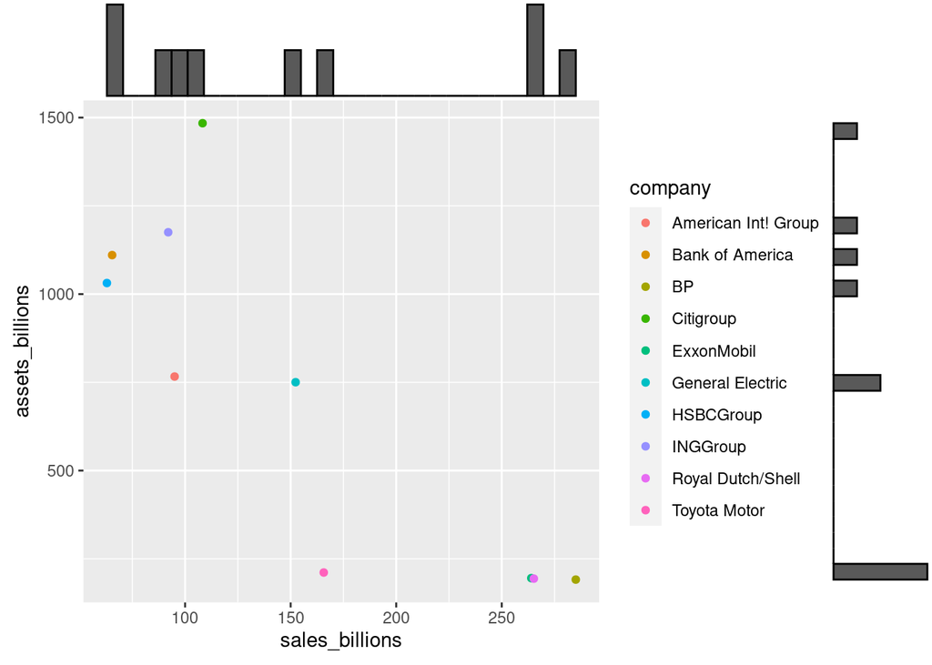

```r
p5a <-
  ggplot() +
  geom_point(
    data = df4,
    mapping = aes(
      x = sales_billions,
      y = assets_billions,
      color = company
    )
  )

ggMarginal(
  p5a,
  type = "histogram"
)
```

Profits and Assets:

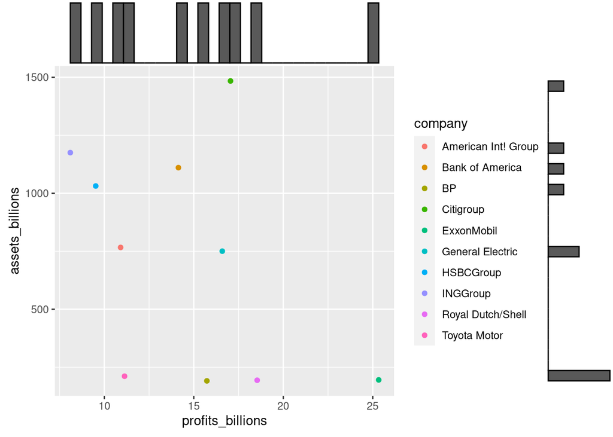

```r
p5b <-
ggplot() +
  geom_point(
    data = df4,
    mapping = aes(
      x= profits_billions,
      y = assets_billions,
      color = company
    )
  )

ggMarginal(
  p5b,
  type ="histogram"
)
```

1.8 P = (-1, -1), Q = (1, 0), p = 2, a11 = 1/3, a12 = 1/9, a22 = 4/27 Find Euclidean distance (simple pythagorean theorem):

```r
first <- (-1 - 1)^2
second <- ((-1)-0)^2
sum_of_squares <- first + second
sqrt(sum_of_squares)
```

```
## [1] 2.236068
```

Find statistical distance:

```r
third <- (-1-1)*((-1)-0)
a11 <- 1/3
a22 <- 4/27
a12 <- 1/9
sqrt(
  (first * a11) * (2 * a12 * third) * (second * a22)
)
```

```
## [1] 0.2962963
```

1.9 Create data frame:

```r
x1 <- c(-6, -3, -2, 1, 2, 5, 6, 8)
x2 <- c(-2, -3, 1, -1, 2, 1, 5, 3)
df9 <- data.frame(
  x1,
  x2
)
print(df9)
```

```
##   x1 x2
## 1 -6 -2
## 2 -3 -3
## 3 -2  1
## 4  1 -1
## 5  2  2
## 6  5  1
## 7  6  5
## 8  8  3
```

Plot scatterplot:

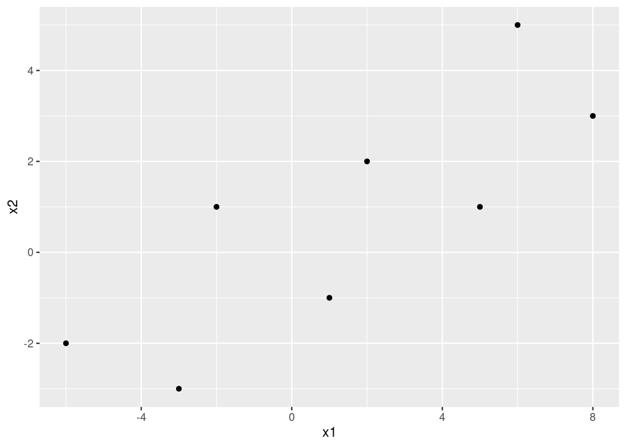

```r
ggplot() +
  geom_point(
    data = df9,
    mapping = aes(
      x= x1,
      y = x2
    )
  )
```

Compute s11, s22, and s12 variance of x1:

```r
var(df9 $ x1)
```

```
## [1] 23.41071
```

variance of x2:

```r
var(df9 $ x2)
```

```
## [1] 7.071429
```

Covariance of x1 and x2:

```r
cov(df9 $ x1, df9 $ x2)
```

```
## [1] 10.39286
```

Find new axes for correlated x1 and x2, which is tilde x1 and tilde x2: theta = 26 degrees, cos (26) = 0.899 and sin (26) = 0.438, x1 = -6, x2 = -2 tilde x1:

```r
x1_tilde <-
  (
    (x1*0.899) + (x2 * 0.438)
    )

print(x1_tilde)
```

```
## [1] -6.270 -4.011 -1.360  0.461  2.674  4.933  7.584  8.506
```

tilde x2:

```r
x2_tilde <-
  (
    (df9$x1 * 0.438) + (df9$x2 *0.889)
  )

print(x2_tilde)
```

```
## [1] -4.406 -3.981  0.013 -0.451  2.654  3.079  7.073  6.171
```

Are the tilde x1 and tilde x2 new axes? Or new points? Need to clarify this The text calls these rotated coordinates, makes me believe new points to plot if shifted axis is moved to fit the original axis of the plot

Find sample variances using tilde x1 and tilde x2: tilde s1:

```r
s1_tilde <-
  var(x1_tilde)

print(s1_tilde)
```

```
## [1] 28.4618
```

tilde s2:

```r
s2_tilde <-
  var(x2_tilde)

print(s2_tilde)
```

```
## [1] 18.17349
```

Using point (4, -2) transform in relation to shifted axes and calculate distance from the origin. Adjusted x value:

```r
Xadjusted <-
   (4*0.899) + (-2 * 0.438)
Yadjusted <-
  (4 * 0.438) + (-2 *0.889)
print(Xadjusted)
```

```
## [1] 2.72
```

Adjusted y value:

```r
print(Yadjusted)
```

```
## [1] -0.026
```

```r
sqrt(
  ((Xadjusted^2)/(s1_tilde)) +
    ((Yadjusted^2)/(s2_tilde))
)
```

```
## [1] 0.509881
```

I would like to practice adding an ellipse to the plot:

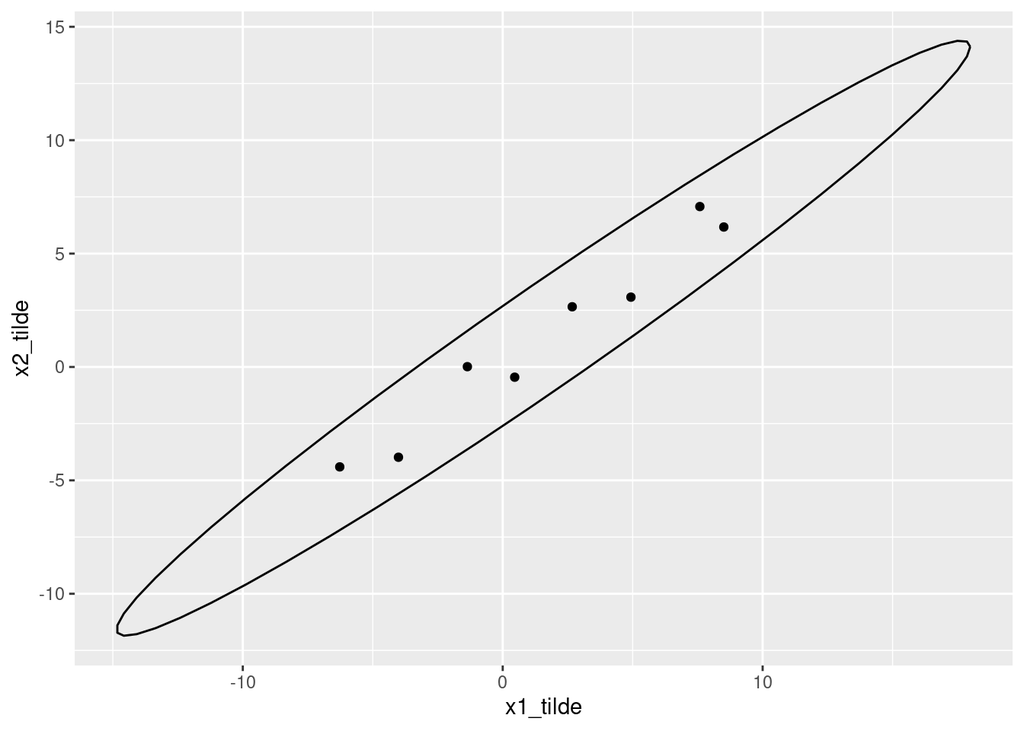

```r
ggplot(
  mapping = aes(
      x= x1_tilde,
      y = x2_tilde
    )
) +
  geom_point() +
  stat_ellipse(
    type = "norm"
  )
```